# Taller Práctico: Introducción a dplyr y ggplot2

# 1. Guía Rápida de R Markdown

R Markdown permite alternar texto con formato, bloques de código ejecutable (chunks) y visualizaciones dentro de un mismo documento interactivo.

### Estructura Básica y Formato de Texto

- **Títulos:** Usa `#` para título principal, `##` para subtítulo, `###` para sección.
- **Formato:** Usa `*cursiva*` para *cursiva*, `**negrita**` para **negrita**, y comillas invertidas para resaltar código en línea.
- **Listas:** Usa guiones `-` o asteriscos `*` para listas no ordenadas.

### Chunks de Código

Los bloques de código se crean con tres comillas invertidas seguidas de `{r}`:

````
``` r
# Tu código R va aquí
summary(cars)
````

```
##      speed           dist
##  Min.   : 4.0   Min.   :  2.00
##  1st Qu.:12.0   1st Qu.: 26.00
##  Median :15.0   Median : 36.00
##  Mean   :15.4   Mean   : 42.98
##  3rd Qu.:19.0   3rd Qu.: 56.00
##  Max.   :25.0   Max.   :120.00
```

[output not shown]

El dataset `iris` contiene mediciones en centímetros de la longitud y ancho del sépalo y pétalo de 150 flores de 3 especies de orquídeas (*Iris setosa*, *Iris versicolor* y *Iris virginica*).

## 2.1 Funciones Básicas de `dplyr`

El paquete `dplyr` facilita la manipulación de datos tabulares mediante el uso de “verbos” secuenciales encadenados por el operador pipe (`%>%` o `|>`).

### A. `filter()`: Filtrar filas por condiciones lógicas

Permite seleccionar un subconjunto de filas basándose en una o más condiciones.

```r
# Filtrar flores cuya longitud de sépalo sea mayor a 6 cm y pertenezcan a la especie versicolor
iris %>%
  filter(Sepal.Length > 6.0, Species == "versicolor") %>%
  head()
```

```
##   Sepal.Length Sepal.Width Petal.Length Petal.Width    Species
## 1          7.0         3.2          4.7         1.4 versicolor
## 2          6.4         3.2          4.5         1.5 versicolor
## 3          6.9         3.1          4.9         1.5 versicolor
## 4          6.5         2.8          4.6         1.5 versicolor
## 5          6.3         3.3          4.7         1.6 versicolor
## 6          6.6         2.9          4.6         1.3 versicolor
```

### B. `select()`: Seleccionar o renombrar columnas

Permite elegir columnas específicas dentro de un dataframe.

```r
# Seleccionar únicamente las variables del pétalo y la especie
iris %>%
  select(Petal.Length, Petal.Width, Species) %>%
  head()
```

```
##   Petal.Length Petal.Width Species
## 1          1.4         0.2  setosa
## 2          1.4         0.2  setosa
## 3          1.3         0.2  setosa
## 4          1.5         0.2  setosa
## 5          1.4         0.2  setosa
## 6          1.7         0.4  setosa
```

### C. `mutate()`: Crear o modificar variables

Permite agregar nuevas columnas calculadas a partir de las existentes.

```r
# Crear una nueva variable que representa la razón entre longitud y ancho del sépalo
iris %>%
  mutate(Sepal.Ratio = Sepal.Length / Sepal.Width) %>%
  select(Sepal.Length, Sepal.Width, Sepal.Ratio, Species) %>%
  head()
```

```
##   Sepal.Length Sepal.Width Sepal.Ratio Species
## 1          5.1         3.5    1.457143  setosa
## 2          4.9         3.0    1.633333  setosa
## 3          4.7         3.2    1.468750  setosa
## 4          4.6         3.1    1.483871  setosa
## 5          5.0         3.6    1.388889  setosa
## 6          5.4         3.9    1.384615  setosa
```

### D. `arrange()`: Ordenar filas

Ordena los registros de acuerdo al valor de una o varias columnas.

```r
# Ordenar de forma descendente según la longitud del pétalo
iris %>%
  arrange(desc(Petal.Length)) %>%
  head()
```

```
##   Sepal.Length Sepal.Width Petal.Length Petal.Width   Species
## 1          7.7         2.6          6.9         2.3 virginica
## 2          7.7         3.8          6.7         2.2 virginica
## 3          7.7         2.8          6.7         2.0 virginica
## 4          7.6         3.0          6.6         2.1 virginica
## 5          7.9         3.8          6.4         2.0 virginica
## 6          7.3         2.9          6.3         1.8 virginica
```

### E. `group_by()` y `summarise()`: Agrupar y resumir datos

Permite calcular métricas estadísticas descriptivas para diferentes subgrupos de datos.

```r
# Calcular el promedio y la desviación estándar de la longitud del sépalo por especie
iris %>%
  group_by(Species) %>%
  summarise(
    Promedio_Sepalo = mean(Sepal.Length),
    Desviacion_Sepalo = sd(Sepal.Length),
    Conteo = n()
  )
```

```
## # A tibble: 3 x 4
##   Species    Promedio_Sepalo Desviacion_Sepalo Conteo
##   <fct>                <dbl>             <dbl>  <int>
## 1 setosa                5.01             0.352     50
## 2 versicolor            5.94             0.516     50
## 3 virginica             6.59             0.636     50
```

## 2.2 Visualización de Datos con `ggplot2`

`ggplot2` funciona mediante una gramática de gráficos basada en capas: 1. `ggplot(data, aes(...))`: Define los datos y los mapeos estéticos ($x$, $y$, colores, etc.). 2. `geom_*()`: Añade capas geométricas (puntos, líneas, cajas). 3. `labs()` y `theme_*()`: Ajusta títulos, etiquetas de ejes y apariencia estética general.

### A. Diagrama de dispersión.

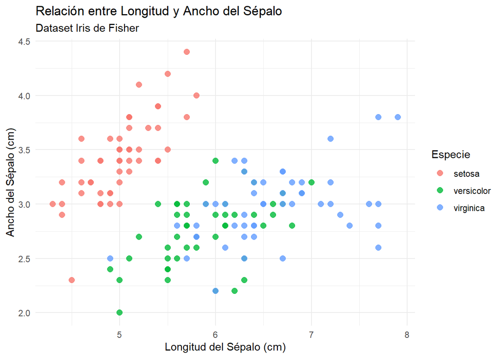

```r
# Paso 1: Definir los datos (iris) y los ejes/colores en aes()

ggplot(data = iris, aes(x = Sepal.Length, y = Sepal.Width, color = Species)) +

# Paso 2: Dibujar los puntos y ajustar su tamaño y transparencia
  geom_point(size = 2.5, alpha = 0.8) +
# Paso 3: Agregar títulos descriptivos y etiquetas a los ejes
  labs(
    title = "Relación entre Longitud y Ancho del Sépalo",
    subtitle = "Dataset Iris de Fisher",
    x = "Longitud del Sépalo (cm)",
    y = "Ancho del Sépalo (cm)",
    color = "Especie"
  ) +
# Paso 4: Aplicar un tema visual limpio con fondo blanco
  theme_minimal()
```

### B. Diagrama de dispersión-Recta de Regresión.

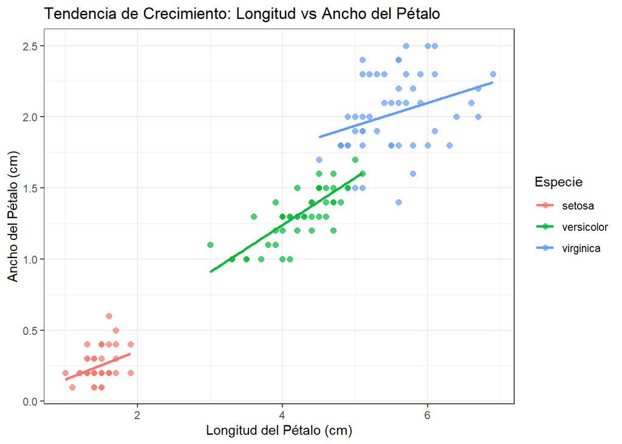

```r
# Paso 1: Definir las variables continua X (longitud pétalo) e Y (ancho pétalo)
ggplot(data = iris, aes(x = Petal.Length, y = Petal.Width, color = Species)) +
# Paso 2: Graficar las observaciones individuales como puntos
  geom_point(size = 2, alpha = 0.7) +
# Paso 3: Trazar la recta de regresión lineal (lm) para cada especie sin el intervalo de confianza (se = FALSE)
  geom_smooth(method = "lm", se = FALSE) +
# Paso 4: Personalizar las etiquetas y el título
  labs(
    title = "Tendencia de Crecimiento: Longitud vs Ancho del Pétalo",
    x = "Longitud del Pétalo (cm)",
    y = "Ancho del Pétalo (cm)",
    color = "Especie"
  ) +
# Paso 5: Usar tema con borde completo alrededor del gráfico
  theme_bw()
```

### C. Diagrama Boxplot.

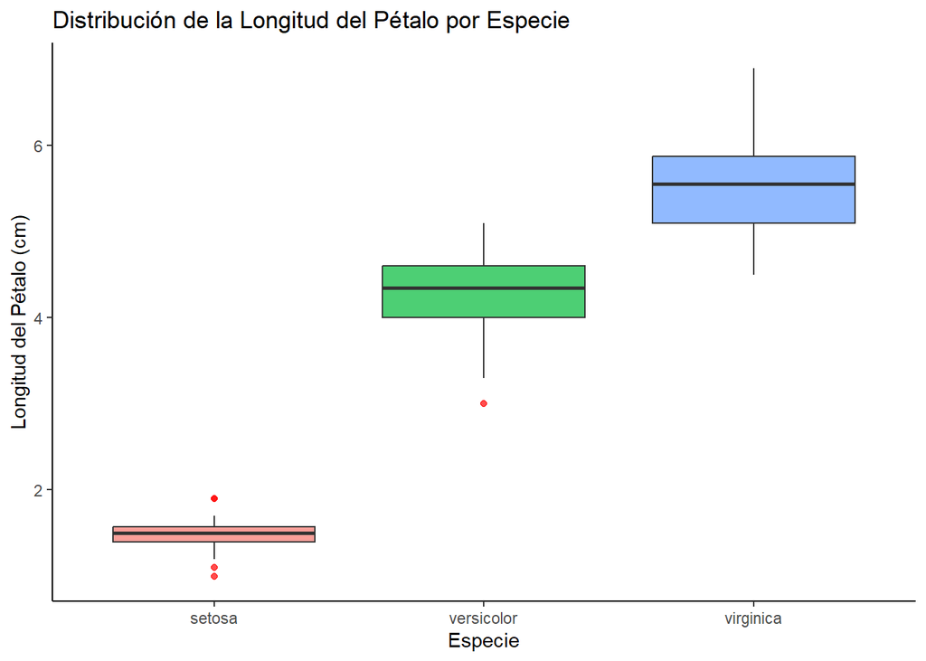

```r
# Paso 1: Mapear la variable categórica en X (especie) y la numérica en Y (longitud del pétalo)
ggplot(data = iris, aes(x = Species, y = Petal.Length, fill = Species)) +
# Paso 2: Crear el gráfico de cajas con relleno de color y resaltando outliers en rojo
  geom_boxplot(alpha = 0.7, outlier.color = "red") +
# Paso 3: Asignar nombres a los ejes y título
  labs(
    title = "Distribución de la Longitud del Pétalo por Especie",
    x = "Especie",
    y = "Longitud del Pétalo (cm)"
  ) +
# Paso 4: Aplicar un tema clásico (sin cuadrícula de fondo)
  theme_classic() +
# Paso 5: Eliminar la leyenda lateral (es redundante porque las especies ya están en el eje X)
  theme(legend.position = "none")
```

### D. Histograma.

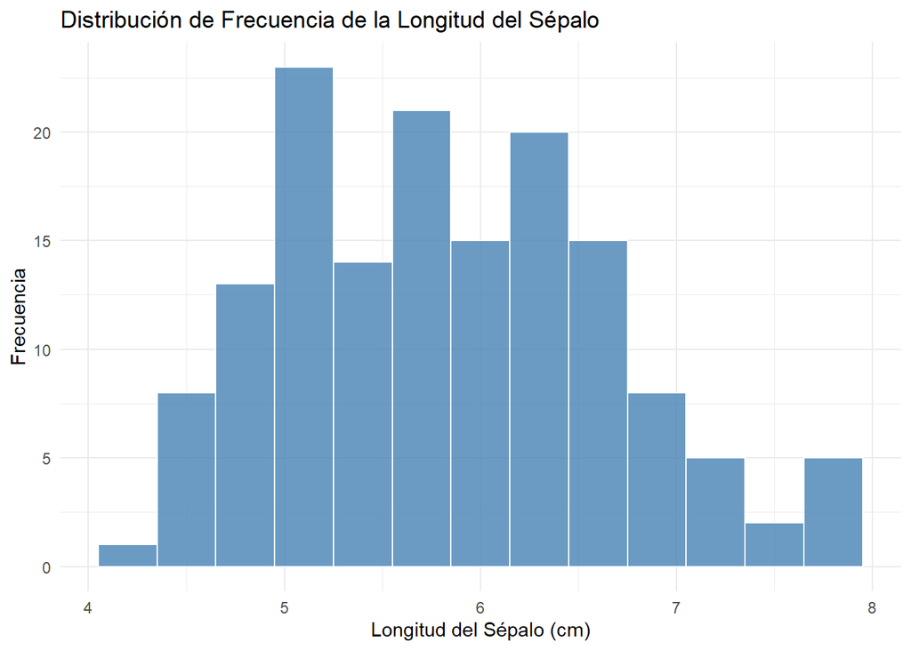

```r
# Paso 1: Definir únicamente la variable continua a analizar en el eje X
ggplot(data = iris, aes(x = Sepal.Length)) +
# Paso 2: Crear el histograma definiendo el ancho de los intervalos (binwidth) y colores
  geom_histogram(binwidth = 0.3, fill = "steelblue", color = "white", alpha = 0.8) +
# Paso 3: Definir los títulos correspondientes
  labs(
    title = "Distribución de Frecuencia de la Longitud del Sépalo",
    x = "Longitud del Sépalo (cm)",
    y = "Frecuencia"
  ) +
# Paso 4: Establecer el tema estético
  theme_minimal()
```

### D. Diagrama de Barras.

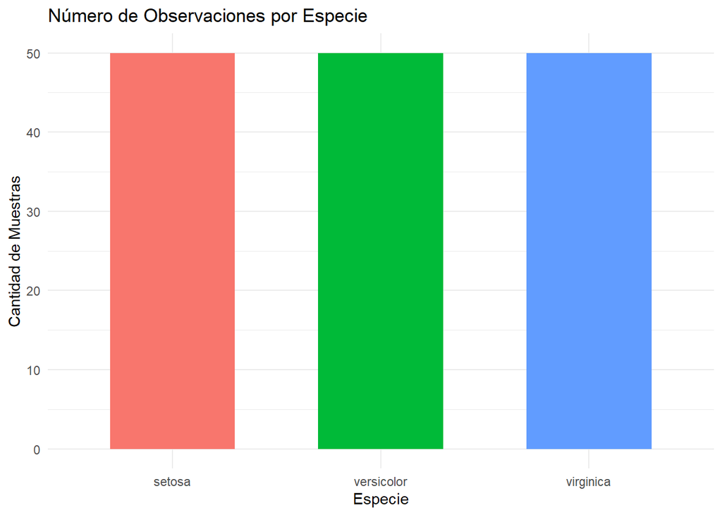

```r
# Paso 1: Usar dplyr para contar el número de flores por cada especie
conteo_especies <- iris %>%
  group_by(Species) %>%
  summarise(Cantidad = n())

# Paso 2: Visualizar los datos agrupados usando geom_col() para representar las alturas calculadas
ggplot(data = conteo_especies, aes(x = Species, y = Cantidad, fill = Species)) +
# Paso 3: Dibujar las barras especificando su grosor (width)
  geom_col(width = 0.6) +
# Paso 4: Personalizar etiquetas
  labs(
    title = "Número de Observaciones por Especie",
    x = "Especie",
    y = "Cantidad de Muestras"
  ) +
# Paso 5: Ajustar tema y quitar la leyenda innecesaria
  theme_minimal() +
  theme(legend.position = "none")
```

# 3. El Dataset `palmerpenguins`

El paquete `palmerpenguins` proporciona un conjunto de datos alternativo al clásico `iris`, recolectado por la Dra. Kristen Gorman en la Estación Palmer de la Antártida. Registra observaciones de 344 pingüinos pertenecientes a tres especies distintas.

### Variables del Dataset:

- **`species`**: Especie del pingüino (*Adelie*, *Chinstrap*, *Gentoo*).
- **`island`**: Isla del Archipiélago Palmer donde fue documentado (*Biscoe*, *Dream*, *Torgersen*).
- **`bill_length_mm`**: Longitud del pico en milímetros (desde la base hasta la punta).
- **`bill_depth_mm`**: Profundidad (alto) del pico en milímetros.
- **`flipper_length_mm`**: Longitud de la aleta en milímetros.
- **`body_mass_g`**: Masa corporal del pingüino en gramos.
- **`sex`**: Sexo del pingüino (*female*, *male*).
- **`year`**: Año del registro (2007, 2008 o 2009).

# 4. Taller Práctico para el Estudiante

**Instrucciones:** Utiliza el paquete `palmerpenguins` para responder los siguientes ejercicios. En todos los pasos debes emplear el operador pipe (`%>%` o `|>`) para la manipulación de datos y la estructuración de tus análisis.

```r
# Carga de paquetes necesarios para el taller
# install.packages("palmerpenguins") # Ejecutar en consola si no está instalado
library(palmerpenguins)
```

### Ejercicio 1: Limpieza y Descriptivos con `dplyr`

1. Filtra los datos para eliminar las observaciones con valores faltantes (`NA`) en la variable `sex`.
2. Agrupa por `species` y `sex`, y calcula la media y la desviación estándar de la masa corporal (`body_mass_g`), así como la cantidad de observaciones por grupo.

### Ejercicio 2: Diagrama de Dispersión (Scatter Plot)

1. Construye un gráfico de dispersión (`geom_point`) que compare la longitud del pico (`bill_length_mm`) en el eje $X$ con la masa corporal (`body_mass_g`) en el eje $Y$.
2. Asigna el color de los puntos según la especie del pingüino (`species`).
3. Agrega títulos descriptivos y ejes etiquetados adecuadamente.

### Ejercicio 3: Incorporación de Regresión Lineal

1. Toma la estructura del gráfico del Ejercicio 2 y añade una capa de regresión lineal simple (`geom_smooth(method = "lm")`).
2. Analiza visualmente si la relación entre la longitud del pico y la masa corporal cambia de acuerdo con la especie.

### Ejercicio 4: Comparación de Distribuciones con Boxplots

1. Crea un diagrama de caja (`geom_boxplot`) para comparar la longitud de las aletas (`flipper_length_mm`) entre las tres especies de pingüinos.
2. Añade color de relleno (`fill`) según la especie y personaliza el tema gráfico con `theme_minimal()`.

# 5. Instrucciones para la Entrega Final

La entrega de esta actividad consta de **dos componentes obligatorios**:

### 1. Documento R Markdown Renderizado (`.html` o `.pdf`)

- Debes crear un **nuevo archivo `.Rmd`** (diferente a esta guía).
- Debe incluir la solución completa a los 4 ejercicios planteados en la Sección 4.
- Cada bloque de código debe estar acompañado por un **párrafo explicativo** que interprete estadísticamente y biológicamente los resultados obtenidos.
- El documento debe compilar correctamente sin errores.

### 2. Presentación en Video (Duración: 3 a 5 minutos)

Debes grabar un video exponiendo la solución de tu taller cumpliendo la siguiente estructura: - **Presentación:** Breve introducción del estudiante y el dataset asignado. - **Demostración en RStudio:** Mostrar la ejecución en vivo del código desarrollado. Explicar qué hace cada función de `dplyr` y `ggplot2` utilizada. - **Interpretación de Resultados:** Mostrar las gráficas generadas (dispersión, regresión y boxplot) e interpretar los hallazgos en relación con las características biológicas de las especies de pingüinos. - **Formato:** Puedes usar herramientas como Loom, Zoom, OBS o Teams para la grabación. Incluye el enlace al video al inicio de tu documento R Markdown.

# 6. Material Bibliográfico y Recursos Recomendados

Para profundizar en el uso de R, la manipulación de datos con `dplyr` y la visualización con `ggplot2`, se recomienda consultar la siguiente literatura de acceso libre y documentación oficial:

### Libros de Referencia (Acceso Libre)

- **R para Ciencia de Datos** (*Hadley Wickham & Garrett Grolemund*): https://es.r4ds.hadley.nz/  
  *(Manual fundamental y traducido al español sobre el ecosistema tidyverse).*
- **R Markdown: The Definitive Guide** (*Yihui Xie, J.J. Allaire, Garrett Grolemund*): https://bookdown.org/yihui/rmarkdown/  
  *(Guía completa para la creación de informes dinámicos y documentos interactivos).*

### Documentación Oficial y Torpedos (Cheatsheets)

- **Hoja de referencia de `dplyr` (Posit Cheatsheets):** https://rstudio.github.io/cheatsheets/data-transformation.pdf
- **Hoja de referencia de `ggplot2` (Posit Cheatsheets):** https://rstudio.github.io/cheatsheets/data-visualization.pdf
- **Documentación oficial del paquete `palmerpenguins`:** https://allisonhorst.github.io/palmerpenguins/

### Sitios Web y Portales Comunitarios

- **R Graph Gallery (Galería de ejemplos de `ggplot2`):** https://r-graph-gallery.com/
- **Posit Primers (Tutoriales interactivos desde el navegador):** https://posit.cloud/learn/primers